# CFSS Homework 03

Cory J. Cascalheira

December 21, 2018

# Part 1

Load dependencies.

```r
library(tidyverse) # utility & visualization
library(readxl) # import excel data
library(lubridate) # convert to date
```

Set the default theme for `ggplot2`.

```r
theme_set(theme_minimal())
```

Load the data.

```r
load("J:/sample_data/dadmom.rda")
dadmom
```

```
## # A tibble: 3 x 5
##   famid named  incd namem  incm
##   <dbl> <chr> <dbl> <chr> <dbl>
## 1     1 Bill  30000 Bess  15000
## 2     2 Art   22000 Amy   18000
## 3     3 Paul  25000 Pat   50000
```

Tidy the data frame.

```r
# Tidy parents and names
(parents <- dadmom %>%
  # Remove income columns
  select(-starts_with("inc")) %>%
  # Gather except family ID
  gather(key = parent, value = name, -famid) %>%
  # Make parent variable make more sense
  mutate(parent = fct_recode(factor(parent), "father" = "named", "mother" = "namem"))
)
```

```
## # A tibble: 6 x 3
##   famid parent name
##   <dbl> <fct>  <chr>
## 1     1 father Bill
## 2     2 father Art
## 3     3 father Paul
## 4     1 mother Bess
## 5     2 mother Amy
## 6     3 mother Pat
```

```r
# Tidy the income, make sure order matches parents
(income <- dadmom %>%
  # Remove name columns
  select(-starts_with("name")) %>%
  # Gather except family ID
  gather(key = parent, value = income, -famid) %>%
  # Drop family ID and parent columns
  select(income)
)
```

```
## # A tibble: 6 x 1
##   income
##    <dbl>
## 1  30000
## 2  22000
## 3  25000
## 4  15000
## 5  18000
## 6  50000
```

```r
# Bind columns
(dadmom_new <- bind_cols(parents, income)
)
```

```
## # A tibble: 6 x 4
##   famid parent name  income
##   <dbl> <fct>  <chr>  <dbl>
## 1     1 father Bill   30000
## 2     2 father Art    22000
## 3     3 father Paul   25000
## 4     1 mother Bess   15000
## 5     2 mother Amy    18000
## 6     3 mother Pat    50000
```

# Part 2

Load the data.

```r
library(gapminder)
hiv <- read_excel("J:/sample_data/hiv-prevalence.xlsx")
hiv
```

```
## # A tibble: 275 x 34
##    `Estimated HIV ~ `1979.0` `1980.0` `1981.0` `1982.0` `1983.0` `1984.0`
##    <chr>               <dbl>    <dbl>    <dbl>    <dbl>    <dbl>    <dbl>
##  1 Abkhazia          NA            NA       NA       NA       NA       NA
##  2 Afghanistan       NA            NA       NA       NA       NA       NA
##  3 Akrotiri and Dh~  NA            NA       NA       NA       NA       NA
##  4 Albania           NA            NA       NA       NA       NA       NA
##  5 Algeria           NA            NA       NA       NA       NA       NA
##  6 American Samoa    NA            NA       NA       NA       NA       NA
##  7 Andorra           NA            NA       NA       NA       NA       NA
##  8 Angola             0.0265       NA       NA       NA       NA       NA
##  9 Anguilla          NA            NA       NA       NA       NA       NA
## 10 Antigua and Bar~  NA            NA       NA       NA       NA       NA
## # ... with 265 more rows, and 27 more variables: `1985.0` <dbl>,
## #   `1986.0` <dbl>, `1987.0` <dbl>, `1988.0` <lgl>, `1989.0` <lgl>,
## #   `1990.0` <dbl>, `1991.0` <dbl>, `1992.0` <dbl>, `1993.0` <dbl>,
## #   `1994.0` <dbl>, `1995.0` <dbl>, `1996.0` <dbl>, `1997.0` <dbl>,
## #   `1998.0` <dbl>, `1999.0` <dbl>, `2000.0` <dbl>, `2001.0` <dbl>,
## #   `2002.0` <dbl>, `2003.0` <dbl>, `2004.0` <dbl>, `2005.0` <dbl>,
## #   `2006.0` <dbl>, `2007.0` <dbl>, `2008.0` <dbl>, `2009` <chr>,
## #   `2010` <chr>, `2011` <chr>
```

Fix the country column.

```r
colnames(hiv)[1] <- "country"
```

Are the same countries in both datasets?

```r
# Which countries are in the gapminder dataset
gapminder_names <- unique(as.character(gapminder$country))

# Filter the HIV dataset to include only those countries in gapminder
(hiv2 <- hiv %>%
  filter(country %in% gapminder_names)
)
```

```
## # A tibble: 139 x 34
##    country `1979.0` `1980.0` `1981.0` `1982.0` `1983.0` `1984.0` `1985.0`
##    <chr>      <dbl>    <dbl>    <dbl>    <dbl>    <dbl>    <dbl>    <dbl>
##  1 Afghan~  NA            NA  NA       NA       NA            NA       NA
##  2 Albania  NA            NA  NA       NA       NA            NA       NA
##  3 Algeria  NA            NA  NA       NA       NA            NA       NA
##  4 Angola    0.0265       NA  NA       NA       NA            NA       NA
##  5 Argent~   0.0205       NA  NA       NA       NA            NA       NA
##  6 Austra~  NA            NA  NA       NA        0.0127       NA       NA
##  7 Austria  NA            NA   0.0102  NA       NA            NA       NA
##  8 Bahrain  NA            NA  NA       NA       NA            NA       NA
##  9 Bangla~  NA            NA  NA       NA       NA            NA       NA
## 10 Belgium  NA            NA  NA        0.0141  NA            NA       NA
## # ... with 129 more rows, and 26 more variables: `1986.0` <dbl>,
## #   `1987.0` <dbl>, `1988.0` <lgl>, `1989.0` <lgl>, `1990.0` <dbl>,
## #   `1991.0` <dbl>, `1992.0` <dbl>, `1993.0` <dbl>, `1994.0` <dbl>,
## #   `1995.0` <dbl>, `1996.0` <dbl>, `1997.0` <dbl>, `1998.0` <dbl>,
## #   `1999.0` <dbl>, `2000.0` <dbl>, `2001.0` <dbl>, `2002.0` <dbl>,
## #   `2003.0` <dbl>, `2004.0` <dbl>, `2005.0` <dbl>, `2006.0` <dbl>,
## #   `2007.0` <dbl>, `2008.0` <dbl>, `2009` <chr>, `2010` <chr>,
## #   `2011` <chr>
```

Tidy the HIV data frame.

```r
(hiv3 <- hiv2 %>%
  gather(key = year, value = hiv_prevalence, -country)
)
```

```
## # A tibble: 4,587 x 3
##    country     year   hiv_prevalence
##    <chr>       <chr>  <chr>
##  1 Afghanistan 1979.0 <NA>
##  2 Albania     1979.0 <NA>
##  3 Algeria     1979.0 <NA>
##  4 Angola      1979.0 0.026527865
##  5 Argentina   1979.0 0.02050798
##  6 Australia   1979.0 <NA>
##  7 Austria     1979.0 <NA>
##  8 Bahrain     1979.0 <NA>
##  9 Bangladesh  1979.0 <NA>
## 10 Belgium     1979.0 <NA>
## # ... with 4,577 more rows
```

Transform year variable into an integer and HIV prevalence into a numeric.

```r
hiv3$year <- as.integer(hiv3$year)
hiv3$hiv_prevalence <- as.numeric(hiv3$hiv_prevalence)

# Verify change
head(hiv3)
```

```
## # A tibble: 6 x 3
##   country      year hiv_prevalence
##   <chr>       <int>          <dbl>
## 1 Afghanistan  1979        NA
## 2 Albania      1979        NA
## 3 Algeria      1979        NA
## 4 Angola       1979         0.0265
## 5 Argentina    1979         0.0205
## 6 Australia    1979        NA
```

## HIV Prevalence & Life Expectancy

I will use a `left_join()` to keep all original columns and observations from `gapminder`, effectively appending the HIV prevalence variable to the dataset.

```r
(gap_hiv <- left_join(gapminder, hiv3, by = c("country", "year")))
```

```
## # A tibble: 1,704 x 7
##    country     continent  year lifeExp      pop gdpPercap hiv_prevalence
##    <chr>       <fct>     <int>   <dbl>    <int>     <dbl>          <dbl>
##  1 Afghanistan Asia       1952    28.8  8425333      779.             NA
##  2 Afghanistan Asia       1957    30.3  9240934      821.             NA
##  3 Afghanistan Asia       1962    32.0 10267083      853.             NA
##  4 Afghanistan Asia       1967    34.0 11537966      836.             NA
##  5 Afghanistan Asia       1972    36.1 13079460      740.             NA
##  6 Afghanistan Asia       1977    38.4 14880372      786.             NA
##  7 Afghanistan Asia       1982    39.9 12881816      978.             NA
##  8 Afghanistan Asia       1987    40.8 13867957      852.             NA
##  9 Afghanistan Asia       1992    41.7 16317921      649.             NA
## 10 Afghanistan Asia       1997    41.8 22227415      635.             NA
## # ... with 1,694 more rows
```

What is the relationship between HIV prevalence and life expectancy?

```r
# Filter out missing values
gap_hiv_complete <- gap_hiv %>%
  filter(!is.na(hiv_prevalence))

# Simple linear model
lm(lifeExp ~ hiv_prevalence, data = gap_hiv_complete)
```

```
##
## Call:
## lm(formula = lifeExp ~ hiv_prevalence, data = gap_hiv_complete)
##
## Coefficients:
##    (Intercept)  hiv_prevalence
##         67.793          -1.424
```

There is a negative relationship between life expectancy and HIV prevalence. For each 1% increase of infection in the adult population, the life expectancy decreases by an average of 1.42 years.

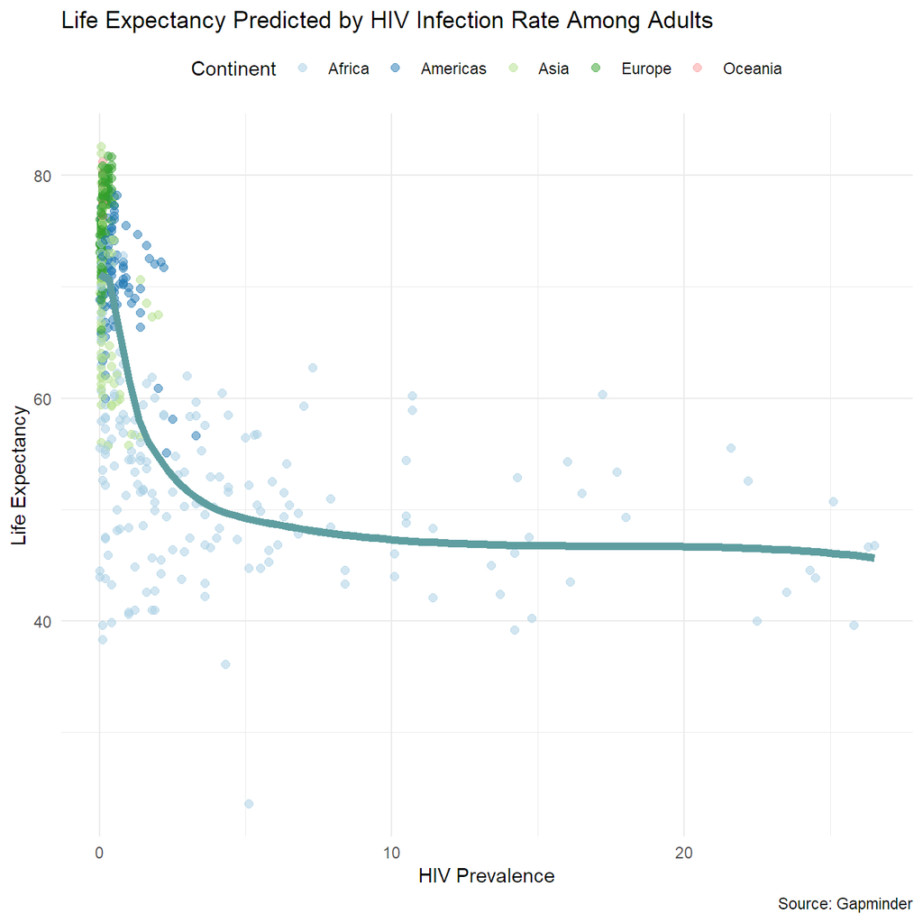

```r
gap_hiv_complete %>%
  # Add continent for more detail
  ggplot(aes(x = hiv_prevalence, y = lifeExp, color = continent)) +
  geom_point(size = 2, alpha = 0.5) +
  # Prevent color aesthetic from inheriting
  geom_smooth(aes(color = NULL), se = FALSE, color = "cadetblue", size = 2) +
  # Provide nice labels
  labs(title = "Life Expectancy Predicted by HIV Infection Rate Among Adults",
       caption = "Source: Gapminder",
       x = "HIV Prevalence",
       y = "Life Expectancy",
       color = "Continent") +
  # Add custom colors
  scale_color_brewer(type = "qual", palette = "Paired") +
  # Move legend
  theme(legend.position = "top")
```

The trend is negative and drops sharply.

## Continents with NA

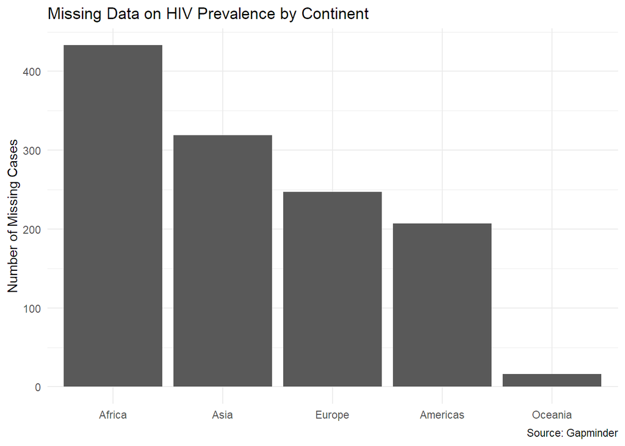

```r
gap_hiv %>%
  group_by(continent) %>%
  # Count missing values
  count(is.na(hiv_prevalence)) %>%
  # Clean column name
  rename("missing" = "is.na(hiv_prevalence)") %>%
  # Filter out non-missing values
  filter(missing == TRUE) %>%
  # Bar chart of results
  ggplot(aes(x = fct_rev(fct_reorder(continent, n)), y = n)) +
    # Use columns instead of bars to plot precise number
    geom_col() +
    # Add labels
    labs(title = "Missing Data on HIV Prevalence by Continent",
         caption = "Source: Gapminder",
         x = NULL,
         y = "Number of Missing Cases")
```

Alarmingly, even though African countries have the most cases of HIV, the dataset is least complete on the African continent. The HIV epidemic is likely more widespread than the data suggest.

# Part 3

Load the two datasets.

```r
modern <- read_csv("J:/sample_data/SCDB_2017_01_justiceCentered_Citation.csv")
legacy <- read_csv("J:/sample_data/SCDB_Legacy_03_justiceCentered_Citation.csv")
```

What do the variables of interest mean?

- `caseIssuesID`: unique key identifier
- `term`: term when decision handed down; has changed over the years
- `justice`: identification number of justices
- `justiceName`: name of justice
- `decisionDirection`: numeric variable; 1 = conservative, 2 = liberal, 3 = unspecified
- `majVotes`: number of justices voting in the majority
- `minVotes`: number fo justices voting in the dissent
- `majority`: whether justice voted with 1 = dissent or 2 = majority
- `chief`: chief justice of the court
- `dateDecision`: date that decision was delivered
- `decisionType`: type of court decision, with values of:
  1. opinion of the court (orally argued)
  2. per curiam (no oral argument)
  3. decrees
  4. equally divided vote
  5. per curiam (orally argued)
  6. judgment of the Court (orally argued)
  7. seriatim

Select only these variables from both datasets.

```r
modern_sm <- modern %>%
  select(caseIssuesId, term, justice, justiceName, decisionDirection,
         majVotes, minVotes, majority, chief, dateDecision, decisionType)

legacy_sm <- legacy %>%
  select(caseIssuesId, term, justice, justiceName, decisionDirection,
         majVotes, minVotes, majority, chief, dateDecision, decisionType)
```

Bind the rows to create a combined data frame.

```r
(supreme <- bind_rows(modern_sm, legacy_sm))
```

```
## # A tibble: 251,072 x 11
##    caseIssuesId  term justice justiceName decisionDirecti~ majVotes
##    <chr>        <dbl>   <dbl> <chr>                  <dbl>    <dbl>
##  1 1946-001-01~  1946      86 HHBurton                   2        8
##  2 1946-001-01~  1946      84 RHJackson                  2        8
##  3 1946-001-01~  1946      81 WODouglas                  2        8
##  4 1946-001-01~  1946      80 FFrankfurt~                2        8
##  5 1946-001-01~  1946      79 SFReed                     2        8
##  6 1946-001-01~  1946      78 HLBlack                    2        8
##  7 1946-001-01~  1946      85 WBRutledge                 2        8
##  8 1946-001-01~  1946      82 FMurphy                    2        8
##  9 1946-001-01~  1946      87 FMVinson                   2        8
## 10 1946-002-01~  1946      86 HHBurton                   1        6
## # ... with 251,062 more rows, and 5 more variables: minVotes <dbl>,
## #   majority <dbl>, chief <chr>, dateDecision <chr>, decisionType <dbl>
```

There was no issue binding the two data frames together. This might be due to the selection of columns prior to binding, or the fact that I downloaded the datasets directly from the Supreme Court Database.

## Percentage of Cases Decided by One-vote Margin

The observational unit is at the individual justice level per case. First, we need to count the number of cases per term.

```r
(cases_per_term <- supreme %>%
  # n represents the number of justices
  count(term, caseIssuesId) %>%
  group_by(term) %>%
  summarize(
    num_cases = n()
  ))
```

```
## # A tibble: 224 x 2
##     term num_cases
##    <dbl>     <int>
##  1  1791         2
##  2  1792         4
##  3  1793         3
##  4  1794         2
##  5  1795         6
##  6  1796        16
##  7  1797         8
##  8  1798         6
##  9  1799         7
## 10  1800         9
## # ... with 214 more rows
```

Count the number of decisions with a one-vote margin per term.

```r
(num_marginal_votes <- supreme %>%
  # Create new margin variable
  mutate(margin = majVotes - minVotes) %>%
  # n represents the number of justices
  count(term, caseIssuesId, margin) %>%
  # Only cases with a one-vote margin
  filter(margin == 1) %>%
  # Group cases by term
  group_by(term) %>%
  summarize(
    num_marginal_votes = n()
  ))
```

```
## # A tibble: 156 x 2
##     term num_marginal_votes
##    <dbl>              <int>
##  1  1794                  1
##  2  1816                  1
##  3  1818                  1
##  4  1822                  1
##  5  1827                  2
##  6  1830                  1
##  7  1837                  1
##  8  1845                  2
##  9  1849                  2
## 10  1850                  6
## # ... with 146 more rows
```

Now, we can `left_join` the two data frames. Missing values for the variable `marginal_votes` indicates that the term had no one-vote margins.

```r
(one_vote_terms <- left_join(cases_per_term, num_marginal_votes, by = "term"))
```

```
## # A tibble: 224 x 3
##     term num_cases num_marginal_votes
##    <dbl>     <int>              <int>
##  1  1791         2                 NA
##  2  1792         4                 NA
##  3  1793         3                 NA
##  4  1794         2                  1
##  5  1795         6                 NA
##  6  1796        16                 NA
##  7  1797         8                 NA
##  8  1798         6                 NA
##  9  1799         7                 NA
## 10  1800         9                 NA
## # ... with 214 more rows
```

Replace the missing values with the number zero. This zero represents an absence of marginal votes, not a margin of zero (which would represent a split vote).

```r
# Which rows are missing values?
(no_margin <- which(is.na(one_vote_terms$num_marginal_votes)))
```

```
##  [1]   1   2   3   5   6   7   8   9  10  11  12  13  14  15  16  17  18
## [18]  19  20  21  22  23  25  27  28  29  31  32  33  34  36  37  39  40
## [35]  41  42  43  44  46  47  48  49  50  51  52  54  55  56  59  60  63
## [52]  66  67  68  69  71  75  76  87  89  95  96  97 121 123 130 131 137
```

```r
# Subset data frame to replace missing values with 0
one_vote_terms$num_marginal_votes[no_margin] <- 0

# Verify that the process worked
head(one_vote_terms)
```

```
## # A tibble: 6 x 3
##    term num_cases num_marginal_votes
##   <dbl>     <int>              <dbl>
## 1  1791         2                  0
## 2  1792         4                  0
## 3  1793         3                  0
## 4  1794         2                  1
## 5  1795         6                  0
## 6  1796        16                  0
```

Percentage of cases decided by a one-vote margin.

```r
one_vote_terms %>%
  mutate(percent_marginal = num_marginal_votes / num_cases)
```

```
## # A tibble: 224 x 4
##     term num_cases num_marginal_votes percent_marginal
##    <dbl>     <int>              <dbl>            <dbl>
##  1  1791         2                  0              0
##  2  1792         4                  0              0
##  3  1793         3                  0              0
##  4  1794         2                  1              0.5
##  5  1795         6                  0              0
##  6  1796        16                  0              0
##  7  1797         8                  0              0
##  8  1798         6                  0              0
##  9  1799         7                  0              0
## 10  1800         9                  0              0
## # ... with 214 more rows
```

A graphical representation of the percentage of decisions involving one-vote margins per term.

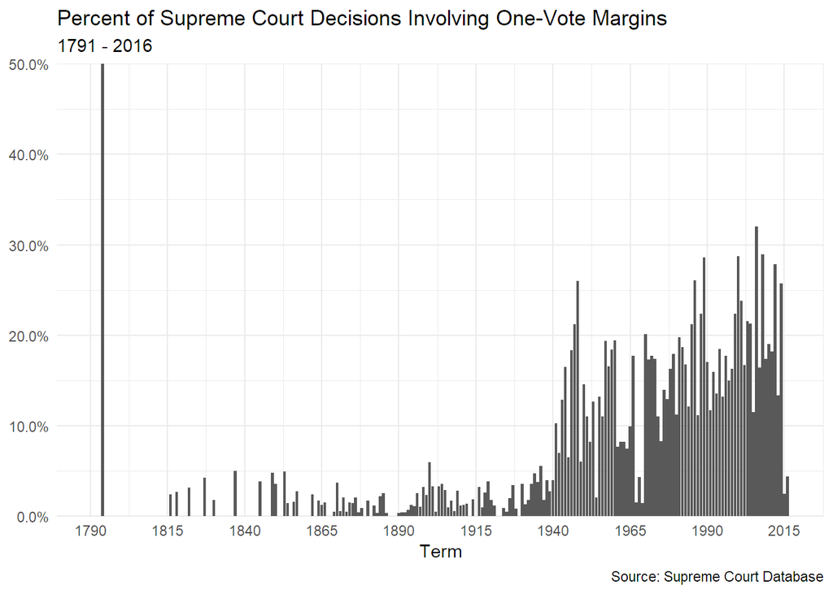

```r
one_vote_terms %>%
  mutate(percent_marginal = num_marginal_votes / num_cases) %>%
#  filter(percent_marginal != 0) %>%
  ggplot(aes(x = term, y = percent_marginal)) +
    geom_col() +
    # Percent added to values on y-axis and force origin to start at 0
    scale_y_continuous(labels = scales::percent, expand = c(0, 0)) +
    # Customize breaks along x-axis
    scale_x_continuous(breaks = seq(1790, 2016, by = 25)) +
    labs(title = "Percent of Supreme Court Decisions Involving One-Vote Margins",
         subtitle = "1791 - 2016",
         x = "Term",
         y = NULL,
         caption = "Source: Supreme Court Database")
```

## Percentage of Cases Justice Antonin Scalia in Majority

Remember, if `majority == 2`, then Justice Scalia was in the majority.

```r
# Total number of cases for Scalia
(scalia_total <- supreme %>%
  filter(justiceName == "AScalia") %>%
 count(term))
```

```
## # A tibble: 30 x 2
##     term     n
##    <dbl> <int>
##  1  1986   161
##  2  1987   153
##  3  1988   152
##  4  1989   140
##  5  1990   129
##  6  1991   120
##  7  1992   119
##  8  1993    96
##  9  1994    92
## 10  1995    91
## # ... with 20 more rows
```

```r
# Cases in which Scalia was in majority
(scalia_majority <- supreme %>%
  filter(justiceName == "AScalia") %>%
  group_by(term, majority) %>%
  summarize(num_majority = n()) %>%
  filter(majority == 2))
```

```
## # A tibble: 30 x 3
## # Groups:   term [30]
##     term majority num_majority
##    <dbl>    <dbl>        <int>
##  1  1986        2          130
##  2  1987        2          122
##  3  1988        2          132
##  4  1989        2          116
##  5  1990        2          106
##  6  1991        2           96
##  7  1992        2          111
##  8  1993        2           84
##  9  1994        2           76
## 10  1995        2           74
## # ... with 20 more rows
```

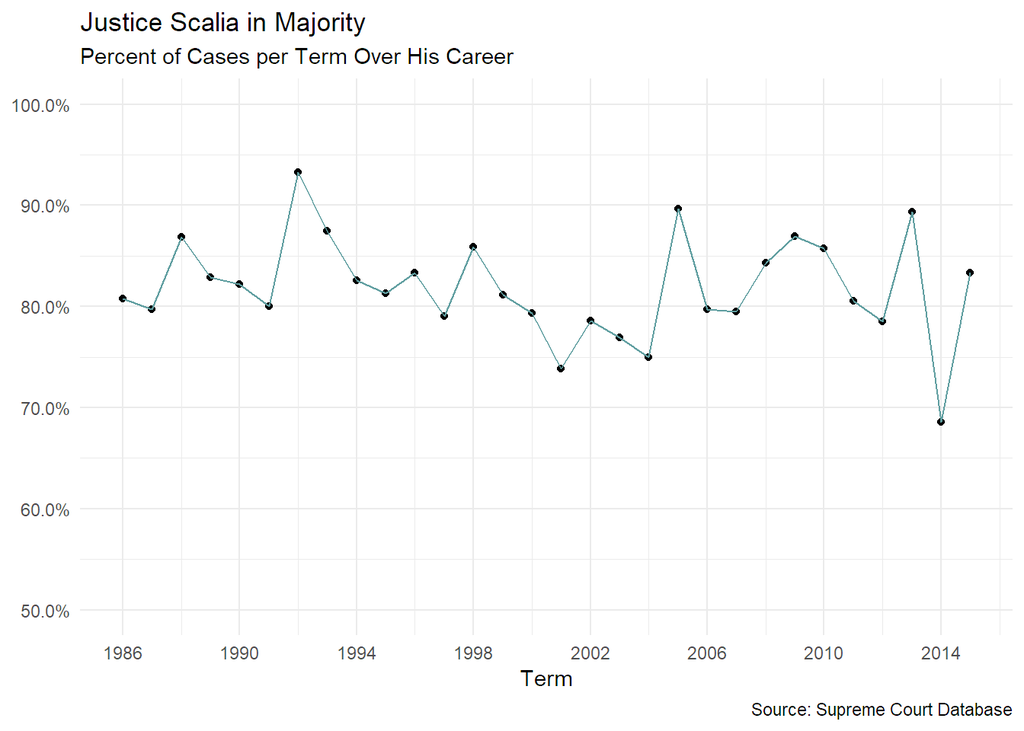

```r
# Join data frames
left_join(scalia_total, scalia_majority, by = "term") %>%
  group_by(term, n, num_majority) %>%
  summarize(percent_majority = num_majority / n) %>%
  ggplot(aes(x = term, y = percent_majority)) +
    geom_point() +
    geom_line(color = "cadetblue") +
    # Scales adds percent sign to values on y-axis
    scale_y_continuous(labels = scales::percent, limits = c(.5, 1)) +
    scale_x_continuous(breaks = seq(1986, 2016, by = 4)) +
    labs(title = "Justice Scalia in Majority",
         subtitle = "Percent of Cases per Term Over His Career",
         x = "Term",
         y = NULL,
         caption = "Source: Supreme Court Database")
```

For most of his career, Justice Scalia voted with the majority opinion on more than 70% of the cases for which he delivered judgement.

## Percentage of Cases Non-Unanimous

We already calculated the number cases per term. This aggregate data frame will be useful in a moment.

```r
head(cases_per_term)
```

```
## # A tibble: 6 x 2
##    term num_cases
##   <dbl>     <int>
## 1  1791         2
## 2  1792         4
## 3  1793         3
## 4  1794         2
## 5  1795         6
## 6  1796        16
```

How many cases were non-unanimous in each term? As long as there is at least one dissent, then the decision was not unanimous. That is, the case is non-unanimous if `minVotes > 0`.

```r
(num_non_unanimous <- supreme %>%
  # Group all justices into each case; n represents number of justices
  count(caseIssuesId, term, minVotes) %>%
  # Only non-unanimous decisions
  filter(minVotes > 0) %>%
  group_by(term) %>%
  # Number of non-unanimous decisions per term
  summarize(
    non_unanimous_decisions = n()
  ))
```

```
## # A tibble: 214 x 2
##     term non_unanimous_decisions
##    <dbl>                   <int>
##  1  1792                       1
##  2  1793                       2
##  3  1795                       2
##  4  1796                       1
##  5  1798                       1
##  6  1806                       1
##  7  1807                       4
##  8  1808                       1
##  9  1809                       5
## 10  1810                       2
## # ... with 204 more rows
```

Now we can merge with the data frame of the sum of cases per term.

```r
head(dissent <- left_join(cases_per_term, num_non_unanimous, by = "term"))
```

```
## # A tibble: 6 x 3
##    term num_cases non_unanimous_decisions
##   <dbl>     <int>                   <int>
## 1  1791         2                      NA
## 2  1792         4                       1
## 3  1793         3                       2
## 4  1794         2                      NA
## 5  1795         6                       2
## 6  1796        16                       1
```

Which observations contain missing values?

```r
(no_dissent <- which(is.na(dissent$non_unanimous_decisions)))
```

```
##  [1]  1  4  7  9 10 11 12 13 14 33
```

Replace those missing values with zero. Zero indicates that all cases for that term were decided unanimously.

```r
dissent$non_unanimous_decisions[no_dissent] <- 0

# Verify that process worked
head(dissent)
```

```
## # A tibble: 6 x 3
##    term num_cases non_unanimous_decisions
##   <dbl>     <int>                   <dbl>
## 1  1791         2                       0
## 2  1792         4                       1
## 3  1793         3                       2
## 4  1794         2                       0
## 5  1795         6                       2
## 6  1796        16                       1
```

Visualize the percentage of cases per term that were non-unanimous.

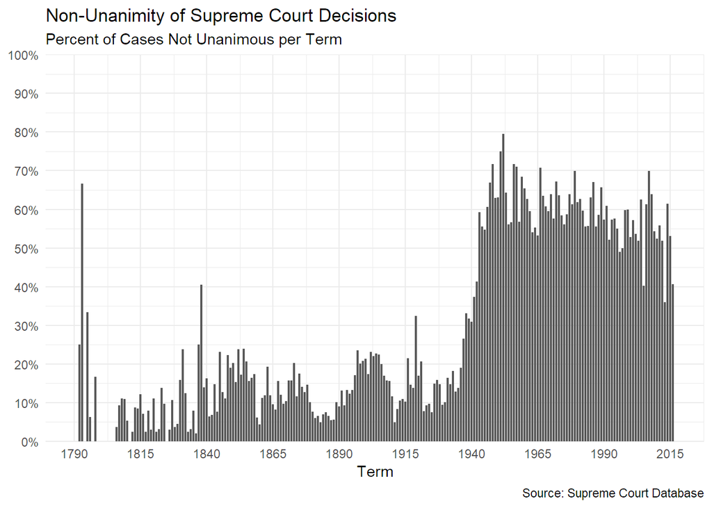

```r
dissent %>%
  # Calculate percentage of non-unanimous cases
  mutate(percent_non_unanimous = non_unanimous_decisions / num_cases) %>%
  ggplot(aes(x = term, y = percent_non_unanimous)) +
    geom_col() +
    # Add percent sign, extend y-axis to 100%, customize breaks, force origin to start at 0
    scale_y_continuous(labels = scales::percent, limits = c(0, 1),
                       breaks = seq(0, 1, 0.1), expand = c(0, 0)) +
    # Customize breaks along x-axis
    scale_x_continuous(breaks = seq(1790, 2016, by = 25)) +
    labs(title = "Non-Unanimity of Supreme Court Decisions",
         subtitle = "Percent of Cases Not Unanimous per Term",
         x = "Term",
         y = NULL,
         caption = "Source: Supreme Court Database")
```

Aside from an outlier in the early 1790s, the graph demonstrates that the non-unanimity of court decisions has increased over time. Has the modern era involved more divisive cases?

## Percentage of Cases in Conservative Direction

Again, we can use our data frame of the sum of cases per term as the denominator of the ratio.

```r
head(cases_per_term)
```

```
## # A tibble: 6 x 2
##    term num_cases
##   <dbl>     <int>
## 1  1791         2
## 2  1792         4
## 3  1793         3
## 4  1794         2
## 5  1795         6
## 6  1796        16
```

First, we need to calculate the number of cases decided in the conservative direction. Remember, if `decisionDirection == 1`, then the case was decided in the conservative direction.

```r
(num_conservative <- supreme %>%
  # Lump individual justices into single cases
  count(term, caseIssuesId, decisionDirection) %>%
  # Keep only the cases where the decision was conservative
  filter(decisionDirection == 1) %>%
  # Group the cases by term
  group_by(term) %>%
  # Number of cases that were conservatively decided
  summarize(
    conservative_decisions = n()
  ))
```

```
## # A tibble: 224 x 2
##     term conservative_decisions
##    <dbl>                  <int>
##  1  1791                      1
##  2  1792                      1
##  3  1793                      1
##  4  1794                      1
##  5  1795                      3
##  6  1796                      3
##  7  1797                      4
##  8  1798                      4
##  9  1799                      3
## 10  1800                      5
## # ... with 214 more rows
```

Join the two data frames and calculate the percentage of conservative decisions.

```r
(conservative <- left_join(cases_per_term, num_conservative, by = "term") %>%
  # Percentage of conservative decisions per term
  mutate(percent_conservative = conservative_decisions / num_cases))
```

```
## # A tibble: 224 x 4
##     term num_cases conservative_decisions percent_conservative
##    <dbl>     <int>                  <int>                <dbl>
##  1  1791         2                      1                0.5
##  2  1792         4                      1                0.25
##  3  1793         3                      1                0.333
##  4  1794         2                      1                0.5
##  5  1795         6                      3                0.5
##  6  1796        16                      3                0.188
##  7  1797         8                      4                0.5
##  8  1798         6                      4                0.667
##  9  1799         7                      3                0.429
## 10  1800         9                      5                0.556
## # ... with 214 more rows
```

Visualize the percentage of decisions in the conservative direction over time.

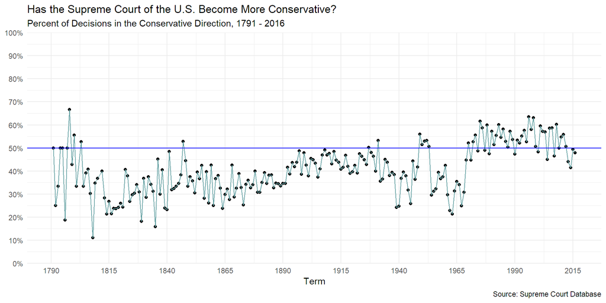

```r
conservative %>%
  ggplot(aes(x = term, y = percent_conservative)) +
    geom_point() +
    # Show trend line
    geom_line(color = "cadetblue") +
    # Add percent signs, breaks, expand the y-axis, and start origin at 0
    scale_y_continuous(labels = scales::percent, breaks = seq(0, 1, 0.1),
                       limits = c(0, 1), expand = c(0, 0)) +
    # Customize breaks along x-axis
    scale_x_continuous(breaks = seq(1790, 2016, by = 25)) +
    # Add horizontal line at 50% for comparison purposes
    geom_hline(yintercept = 0.5, color = "blue") +
    labs(title = "Has the Supreme Court of the U.S. Become More Conservative?",
         subtitle = "Percent of Decisions in the Conservative Direction, 1791 - 2016",
         x = "Term",
         y = NULL,
         caption = "Source: Supreme Court Database")
```

## Decisions per Month

Start by transforming the `dateDecision` variable into a date.

```r
supreme$dateDecision <- mdy(supreme$dateDecision)

# Did the transformation work?
class(supreme$dateDecision)
```

```
## [1] "Date"
```

Create a new column for the month that the decision was delivered, then group the cases by term and month to count the decisions per month. For fun, we can answer the question visually in one long pipeline.

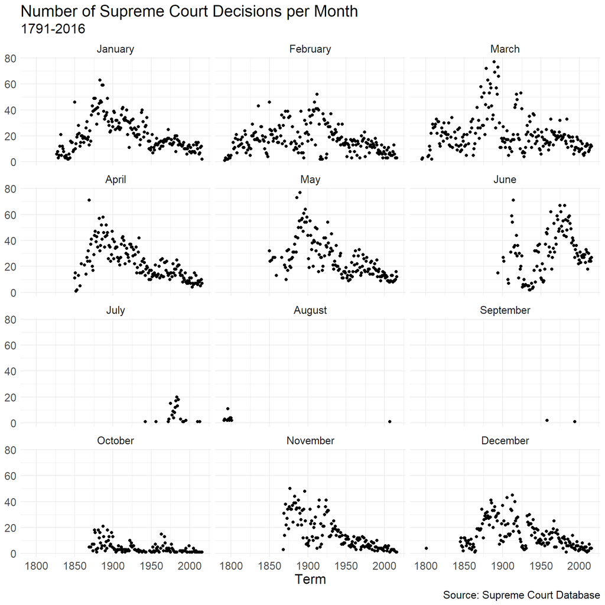

```r
supreme %>%
  # Create the month variable
  mutate(month = month(dateDecision)) %>%
  # Condense the justices into one case, pass along month column
  count(term, caseIssuesId, month) %>%
  # Group by the months per term
  group_by(term, month) %>%
  # Count the number of decisions delivered in a particular month
  summarize(
    num_decisions = n()
  ) %>%
  ggplot(aes(x = term, y = num_decisions)) +
    geom_point() +
    facet_wrap(~ fct_recode(factor(month),
                            "January" = "1",
                            "February" = "2",
                            "March" = "3",
                            "April" = "4",
                            "May" = "5",
                            "June" = "6",
                            "July" = "7",
                            "August" = "8",
                            "September" = "9",
                            "October" = "10",
                            "November" = "11",
                            "December" = "12"),
               ncol = 3) +
    labs(title = "Number of Supreme Court Decisions per Month",
         subtitle = "1791-2016",
         x = "Term",
         y = NULL,
         caption = "Source: Supreme Court Database") +
    # Change default text size
    theme(text = element_text(size = 16))
```